# Econ 294 Final

Tiffany Casali

Winter 2016

### Part A

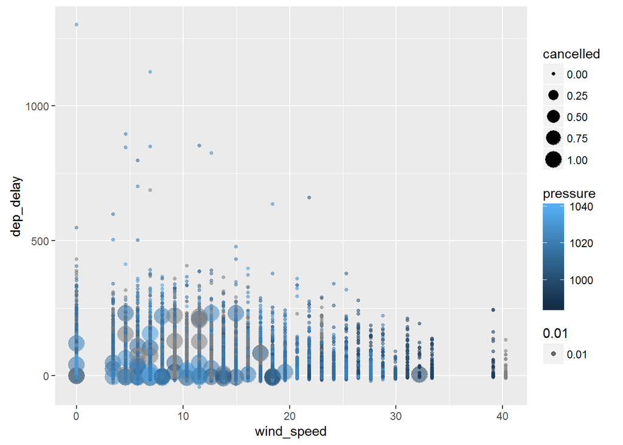

The graph above shows the relationship between wind speed and departure delay, as well as different pressure levels and cancelled flights. This graph shows that there tend to be more departure delays and and cancelled flights with lower wind speeds and higher pressure.

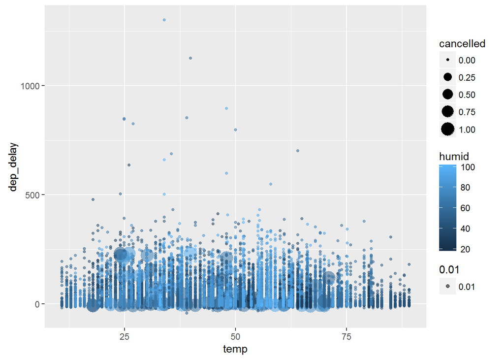

This graph shows the relationship between temperature and departure delay, accounting for humidity and cancelled flights. There does not seem to be a strong relationship between temperature and amount of departure delay, though there do appear to be somewhat more delays (and more extended delays), when temperatures are between 25 and 60 degrees. This may just be due to more observations existing for milder temperatures though.

### Part B

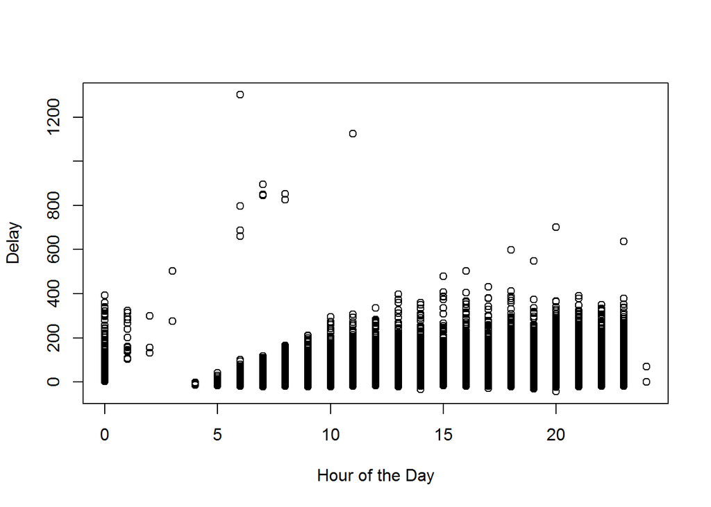

The graph above shows that there tend to be more delays at later hours of the day/evening, rather than the early morning hours. However, delays in the morining are more likely to be severe.

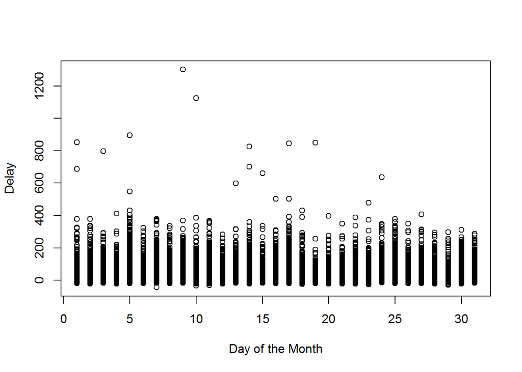

There does not seem to be a large difference in delays across different days of the month, however, there do appear to be slightly more unusually long delays towards the middle of the month.

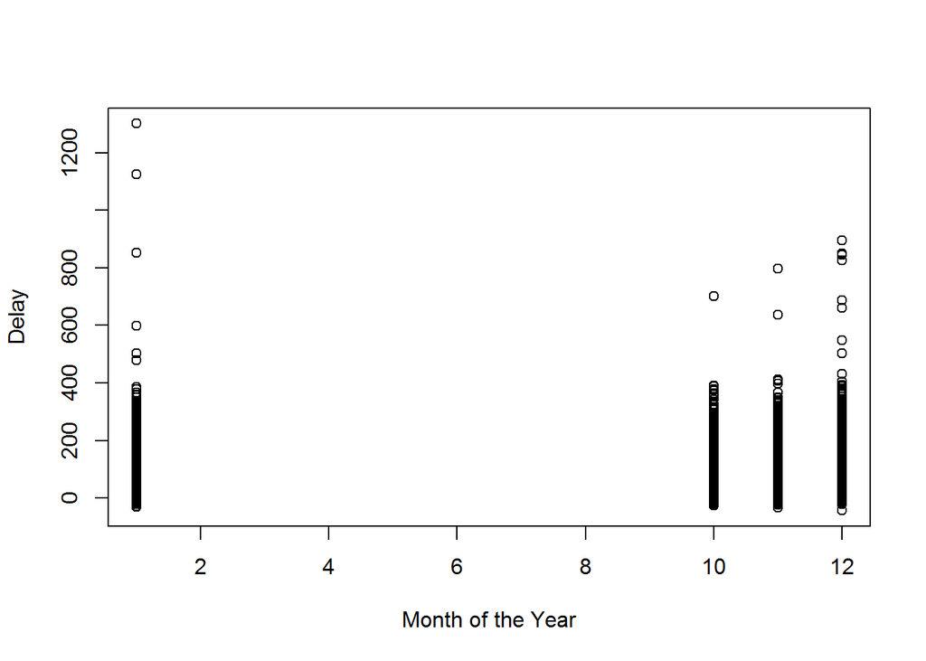

```r
summary(can.hour)
```

```
##
## Call:
## glm(formula = flights$cancelled ~ flights$hour, family = binomial(link = "probit"))
##
## Deviance Residuals:
##     Min       1Q   Median       3Q      Max
## -0.0419  -0.0392  -0.0377  -0.0362   3.8494
##
## Coefficients:
##               Estimate Std. Error z value Pr(>|z|)
## (Intercept)  -3.264279   0.103370 -31.579   <2e-16 ***
## flights$hour  0.005637   0.007215   0.781    0.435
## ---
## Signif. codes:  0 '***' 0.001 '**' 0.01 '*' 0.05 '.' 0.1 ' ' 1
##
## (Dispersion parameter for binomial family taken to be 1)
##
##     Null deviance: 1154.3  on 98105  degrees of freedom
## Residual deviance: 1153.7  on 98104  degrees of freedom
##   (1894 observations deleted due to missingness)
## AIC: 1157.7
##
## Number of Fisher Scoring iterations: 9
```

This regression does not show a significant relationship between hour of flight and and cancellations.

```r
summary(can.day)
```

```
##
## Call:
## glm(formula = flights$cancelled ~ flights$day, family = binomial(link = "probit"))
##
## Deviance Residuals:
##     Min       1Q   Median       3Q      Max
## -0.2034  -0.2015  -0.1994  -0.1969   2.8215
##
## Coefficients:
##              Estimate Std. Error  z value Pr(>|z|)
## (Intercept) -2.042875   0.018002 -113.478   <2e-16 ***
## flights$day -0.001258   0.001064   -1.182    0.237
## ---
## Signif. codes:  0 '***' 0.001 '**' 0.01 '*' 0.05 '.' 0.1 ' ' 1
##
## (Dispersion parameter for binomial family taken to be 1)
##
##     Null deviance: 19327  on 99999  degrees of freedom
## Residual deviance: 19326  on 99998  degrees of freedom
## AIC: 19330
##
## Number of Fisher Scoring iterations: 6
```

There also does not appear to be a significant relationship between day of the month and number of cancellations.

```r
summary(can.month)
```

```
##
## Call:
## glm(formula = flights$cancelled ~ flights$month, family = binomial(link = "probit"))
##
## Deviance Residuals:
##     Min       1Q   Median       3Q      Max
## -0.2076  -0.2053  -0.2029  -0.1829   2.8635
##
## Coefficients:
##                Estimate Std. Error  z value Pr(>|z|)
## (Intercept)   -2.139568   0.020560 -104.066  < 2e-16 ***
## flights$month  0.009364   0.002165    4.325 1.52e-05 ***
## ---
## Signif. codes:  0 '***' 0.001 '**' 0.01 '*' 0.05 '.' 0.1 ' ' 1
##
## (Dispersion parameter for binomial family taken to be 1)
##
##     Null deviance: 19327  on 99999  degrees of freedom
## Residual deviance: 19307  on 99998  degrees of freedom
## AIC: 19311
##
## Number of Fisher Scoring iterations: 6
```

Using this regression, there does appear to be a significant positive relationship between month of the year and flight cancellations.

### Part C

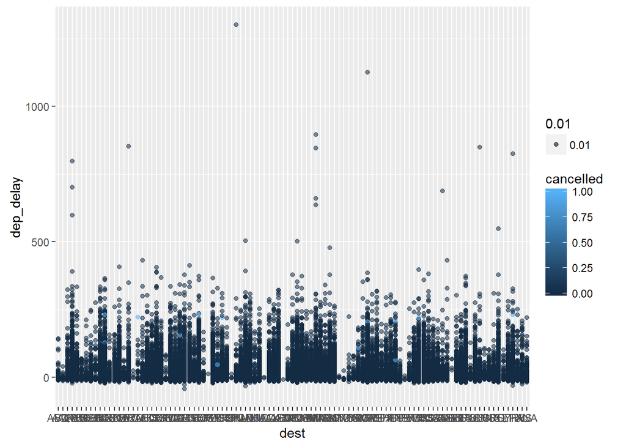

Visually, there does not seem to be any individual destination with particularly unusual delays. There are however a few destinations with nearly no delays. Additionally, destinations with a larger number of delays tend to have longer delays. They are also more likely to have cancellations.

### Part D

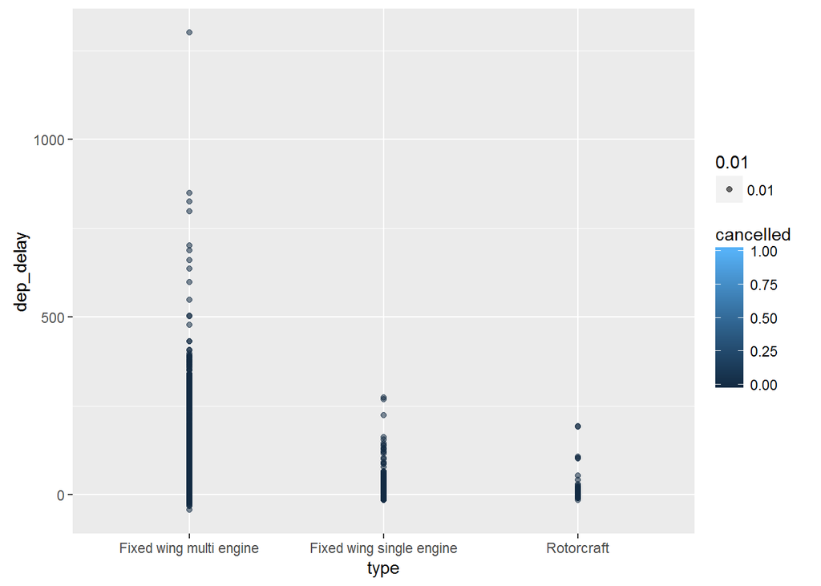

We can see with this graph that a Fixed wing multi engine is by far the most likely type of plane to suffer from a delay (and from unusually long delays), followed by a Fixed wing single engine, then a Rotorcraft (which suffers from the least delays).

```r
summary(can.type)
```

```
##
## Call:
## glm(formula = flights.planes$cancelled ~ flights.planes$type,
##     family = binomial(link = "probit"))
##
## Deviance Residuals:
##     Min       1Q   Median       3Q      Max
## -0.2359  -0.1546  -0.1546  -0.1546   2.9776
##
## Coefficients:
##                                             Estimate Std. Error  z value
## (Intercept)                                 -2.26108    0.01208 -187.195
## flights.planes$typeFixed wing single engine  0.34143    0.11512    2.966
## flights.planes$typeRotorcraft                0.12313    0.28125    0.438
##                                             Pr(>|z|)
## (Intercept)                                  < 2e-16 ***
## flights.planes$typeFixed wing single engine  0.00302 **
## flights.planes$typeRotorcraft                0.66154
## ---
## Signif. codes:  0 '***' 0.001 '**' 0.01 '*' 0.05 '.' 0.1 ' ' 1
##
## (Dispersion parameter for binomial family taken to be 1)
##
##     Null deviance: 10978  on 84575  degrees of freedom
## Residual deviance: 10971  on 84573  degrees of freedom
##   (15424 observations deleted due to missingness)
## AIC: 10977
##
## Number of Fisher Scoring iterations: 7
```

From this regression we can see that having a fixed wing single engine on a plane can has appears to have a significant positive effect on flight cancelations (versus a fixed wing multi engine, which is included in the intercept). A Rotorcraft appears to have a positive effect as well, but it is not statistically significant.